# Using the `stormwindmodel` package

G. Brooke Anderson, Andrea Schumacher, Seth Guikema, Joshua M. Ferreri, Steven Quiring

2018-01-30

## Overview

You can use the `stormwindmodel` package to model wind speeds at grid points in the United States based on “best tracks” hurricane tracking data and on a model for wind speed developed by Willoughby and coauthors (2006).

This package is currently in development on GitHub. You can install it using (you will need to install `devtools` if you do not already have it):

```r
devtools::install_github("geanders/stormwindmodel", build_vignettes = TRUE)
```

The package includes data on the tracks of Hurricane Floyd in 1999. You can load this example best tracks data using:

```r
library(stormwindmodel)
data("floyd_tracks")
head(floyd_tracks)
```

```
## # A tibble: 6 x 4
##           date latitude longitude  wind
##          <chr>    <dbl>     <dbl> <dbl>
## 1 199909071800     14.6     -45.6    25
## 2 199909080000     15.0     -46.9    30
## 3 199909080600     15.3     -48.2    35
## 4 199909081200     15.8     -49.6    40
## 5 199909081800     16.3     -51.1    45
## 6 199909090000     16.7     -52.6    45
```

You must have your storm tracks in this format and with these columns names to input the tracks to the functions in `stormwindmodel`. If necessary, use `rename` from `dplyr` to rename columns and `convert_wind_speed` from `weathermetrics` to convert windspeed into knots.

```r
data(county_points)
head(county_points)
```

```
##   gridid     glat      glon
## 1  01001 32.50039 -86.49416
## 2  01003 30.54892 -87.76238
## 3  01005 31.84404 -85.31004
## 4  01007 33.03092 -87.12766
## 5  01009 33.95524 -86.59149
## 6  01011 32.11633 -85.70119
```

## Basic example

The main function of this package is `get_grid_winds`. It inputs storm tracks for a tropical cyclone and a dataframe with grid point locations and outputs summaries of wind at each grid point from the storm. The wind measurements generated for each grid point are:

- `vmax_gust`: Maximum 10-m 1-minute gust wind experienced at the grid point during the storm
- `vmax_sust`: Maximum 10-m 1-minute sustained wind experienced at the grid point during the storm
- `gust_dur`: Duration gust wind was at or above a specified speed (default is 20 m/s) in minutes
- `sust_dur`: Duration sustained wind was at or above a specified speed (default is 20 m/s) in minutes

To get modeled winds for Hurricane Floyd at U.S. county centers, you can run:

```r
floyd_winds <- get_grid_winds(hurr_track = floyd_tracks,
                              grid_df = county_points)
floyd_winds %>%
  dplyr::select(gridid, vmax_gust, vmax_sust, gust_dur, sust_dur) %>%
  slice(1:6)
```

```
## # A tibble: 6 x 5
##   gridid vmax_gust vmax_sust gust_dur sust_dur
##    <chr>     <dbl>     <dbl>    <dbl>    <dbl>
## 1  01001  2.969661  1.993061        0        0
## 2  01003  1.929468  1.294945        0        0
## 3  01005  4.800611  3.221887        0        0
## 4  01007  2.312488  1.552005        0        0
## 5  01009  2.609132  1.751095        0        0
## 6  01011  4.076456  2.735877        0        0
```

If you model winds for county centers, so the `gridid` is a county FIPS, the `stormwindmodel` package has a function called `map_wind` for mapping the estimated winds. By default, it maps the maximum sustained wind in each county during the storm in meters per second.

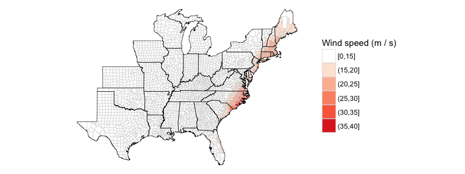

```r
map_wind(floyd_winds)
```

## Further functionality

There are a number of options when mapping wind speeds using `map_wind`.

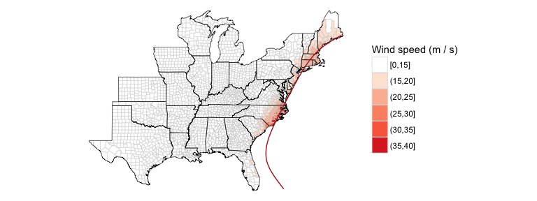

```r
floyd_map <- map_wind(floyd_winds)
add_storm_track(floyd_tracks, plot_object = floyd_map)
```

You can also choose whether to map sustained or gust winds, as well as the unit to use for wind speed.

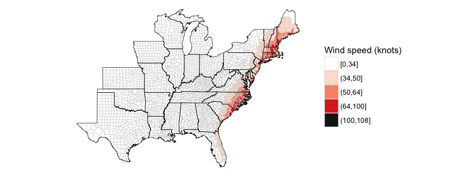

```r
map_wind(floyd_winds, value = "vmax_gust", wind_metric = "knots")
```

Finally, you can map a binary classification of counties with winds at or above a certain break point. For example, to map counties with sustained wind at or above 34 knots during the storm, you can run:

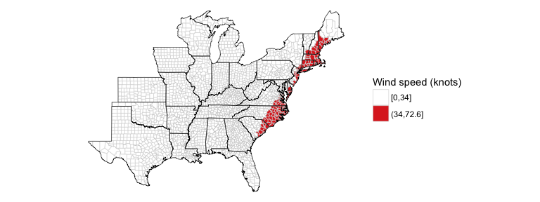

```r
map_wind(floyd_winds, value = "vmax_sust", wind_metric = "knots",
         break_point = 34)
```

## Tracks data

You can get an R version of this data for Atlantic basin storms from 1988 to 2015 through the `hurricaneexposuredata` package (also in development on GitHub):

```r
devtools::install_github("geanders/hurricaneexposuredata")
library(hurricaneexposuredata)
data("hurr_tracks")
```

# References

Willoughby, HE, RWR Darling, and ME Rahn. 2006. “Parametric Representation of the Primary Hurricane Vortex. Part II: A New Family of Sectionally Continuous Profiles.” *Monthly Weather Review* 134 (4): 1102–20.